# Lesson 5: Human in the Loop

Note: This notebook is running in a later version of langgraph that it was filmed with. The later version has a couple of key additions:

- Additional state information is stored to memory and displayed when using `get_state()` or `get_state_history()`.
- State is additionally stored every state transition while previously it was stored at an interrupt or at the end. These change the command output slightly, but are a useful addtion to the information available.

```python
from dotenv import load_dotenv

_ = load_dotenv()
```

```python
from langgraph.graph import StateGraph, END
from typing import TypedDict, Annotated
import operator
from langchain_core.messages import AnyMessage, SystemMessage, HumanMessage, ToolMessage
from langchain_openai import ChatOpenAI
from langchain_community.tools.tavily_search import TavilySearchResults
from langgraph.checkpoint.sqlite import SqliteSaver

memory = SqliteSaver.from_conn_string(":memory:")
```

```python
from uuid import uuid4
from langchain_core.messages import AnyMessage, SystemMessage, HumanMessage, AIMessage

"""
In previous examples we've annotated the `messages` state key
with the default `operator.add` or `+` reducer, which always
appends new messages to the end of the existing messages array.

However, for these human-in-the-loop interactions, we may want to actually replace existing messages.
In order to do that, we annotate the `messages` key with a customer reducer function, which replaces
messages with the same `id`, and appends them otherwise.
"""
def reduce_messages(left: list[AnyMessage], right: list[AnyMessage]) -> list[AnyMessage]:
    # assign ids to messages that don't have them
    for message in right:
        if not message.id:
            message.id = str(uuid4())
    # merge the new messages with the existing messages
    merged = left.copy()
    for message in right:
        for i, existing in enumerate(merged):
            # replace any existing messages with the same id
            if existing.id == message.id:
                merged[i] = message
                break
        else:
            # append any new messages to the end
            merged.append(message)
    return merged

class AgentState(TypedDict):
    messages: Annotated[list[AnyMessage], reduce_messages]
```

```python
tool = TavilySearchResults(max_results=2)
```

## Manual human approval

```python
class Agent:
    def __init__(self, model, tools, system="", checkpointer=None):
        self.system = system
        graph = StateGraph(AgentState)
        graph.add_node("llm", self.call_openai)
        graph.add_node("action", self.take_action)
        graph.add_conditional_edges("llm", self.exists_action, {True: "action", False: END})
        graph.add_edge("action", "llm")
        graph.set_entry_point("llm")

        """
        interrupt_before is going to add an interrupt before we call the action node.
        So the action node is where we call the tools.
        The reason is we're going to add something that requires manual approval before we run any tools.

        The below implementation will add interrupt to all tools.
        For only interrput to certain tools, check the document of compile.
        """
        self.graph = graph.compile(
            checkpointer=checkpointer,
            interrupt_before=["action"]
        )
        self.tools = {t.name: t for t in tools}
        self.model = model.bind_tools(tools)

    def call_openai(self, state: AgentState):
        messages = state['messages']
        if self.system:
            messages = [SystemMessage(content=self.system)] + messages
        message = self.model.invoke(messages)
        return {'messages': [message]}

    def exists_action(self, state: AgentState):
        print(state)
        result = state['messages'][-1]
        return len(result.tool_calls) > 0

    def take_action(self, state: AgentState):
        tool_calls = state['messages'][-1].tool_calls
        results = []
        for t in tool_calls:
            print(f"Calling: {t}")
            result = self.tools[t['name']].invoke(t['args'])
            results.append(ToolMessage(tool_call_id=t['id'], name=t['name'], content=str(result)))
        print("Back to the model!")
        return {'messages': results}
```

```python
prompt = """You are a smart research assistant. Use the search engine to look up information. \
You are allowed to make multiple calls (either together or in sequence). \
Only look up information when you are sure of what you want. \
If you need to look up some information before asking a follow up question, you are allowed to do that!
"""
model = ChatOpenAI(model="gpt-3.5-turbo")
abot = Agent(model, [tool], system=prompt, checkpointer=memory)
```

```python
messages = [HumanMessage(content="Whats the weather in SF?")]
thread = {"configurable": {"thread_id": "1"}}
for event in abot.graph.stream({"messages": messages}, thread):
    for v in event.values():
        print(v)

# The agent will stop when there is an AIMessage(content='', additional_kwargs={'tool_calls'...
```

```
{'messages': [HumanMessage(content='Whats the weather in SF?', id='bc19af27-80f3-4f15-9d0b-3fcc7914b6e9'), AIMessage(content='', additional_kwargs={'tool_calls': [{'id': 'call_8l0swBXiZ41sHlCQRVvnG27g', 'function': {'arguments': '{"query":"weather in San Francisco"}', 'name': 'tavily_search_results_…
{'messages': [AIMessage(content='', additional_kwargs={'tool_calls': [{'id': 'call_8l0swBXiZ41sHlCQRVvnG27g', 'function': {'arguments': '{"query":"weather in San Francisco"}', 'name': 'tavily_search_results_json'}, 'type': 'function'}]}, response_metadata={'token_usage': {'completion_tokens': 21, 'p…
```

```python
# The state of this graph at this point and time
abot.graph.get_state(thread)
```

```
StateSnapshot(values={'messages': [HumanMessage(content='Whats the weather in SF?', id='bc19af27-80f3-4f15-9d0b-3fcc7914b6e9'), AIMessage(content='', additional_kwargs={'tool_calls': [{'function': {'arguments': '{"query":"weather in San Francisco"}', 'name': 'tavily_search_results_json'}, 'id': 'cal…
```

```python
# This is the node to be called next, which is an action
abot.graph.get_state(thread).next
```

```
('action',)
```

### continue after interrupt

We'll get the ToolMessage() and the final AIMessage(). Notice that there was no break in between the action node and the LLM node, because we didn't add any interrupt there.

```python
# Use abot.graph.stream(None, thread) to continue
for event in abot.graph.stream(None, thread):
    for v in event.values():
        print(v)
```

```
Calling: {'name': 'tavily_search_results_json', 'args': {'query': 'weather in San Francisco'}, 'id': 'call_8l0swBXiZ41sHlCQRVvnG27g'}
Back to the model!
{'messages': [ToolMessage(content='[{\'url\': \'https://www.weatherapi.com/\', \'content\': "{\'location\': {\'name\': \'San Francisco\', \'region\': \'California\', \'country\': \'United States of America\', \'lat\': 37.78, \'lon\': -122.42, \'tz_id\': \'America/Los_Angeles\', \'localtime_epoch\': …
{'messages': [HumanMessage(content='Whats the weather in SF?', id='bc19af27-80f3-4f15-9d0b-3fcc7914b6e9'), AIMessage(content='', additional_kwargs={'tool_calls': [{'function': {'arguments': '{"query":"weather in San Francisco"}', 'name': 'tavily_search_results_json'}, 'id': 'call_8l0swBXiZ41sHlCQRVv…
{'messages': [AIMessage(content='The current weather in San Francisco is partly cloudy with a temperature of 55.0°F (12.8°C). The wind speed is 15.1 km/h coming from the WNW direction. The humidity is at 100%, and the visibility is 9.0 miles.', response_metadata={'token_usage': {'completion_tokens':…
```

```python
abot.graph.get_state(thread) # return the full list of messages
```

```
StateSnapshot(values={'messages': [HumanMessage(content='Whats the weather in SF?', id='bc19af27-80f3-4f15-9d0b-3fcc7914b6e9'), AIMessage(content='', additional_kwargs={'tool_calls': [{'function': {'arguments': '{"query":"weather in San Francisco"}', 'name': 'tavily_search_results_json'}, 'id': 'cal…
```

```python
abot.graph.get_state(thread).next # Nothing left to be done
```

```
()
```

### Adding an input box when the graph is interruptted

```python
messages = [HumanMessage("Whats the weather in LA?")]
thread = {"configurable": {"thread_id": "2"}}
for event in abot.graph.stream({"messages": messages}, thread):
    for v in event.values():
        print(v)
while abot.graph.get_state(thread).next:
    print("\n", abot.graph.get_state(thread),"\n")
    _input = input("proceed?")
    if _input != "y":
        print("aborting")
        break
    for event in abot.graph.stream(None, thread):
        for v in event.values():
            print(v)
```

```
{'messages': [HumanMessage(content='Whats the weather in LA?', id='3a72f092-39db-4b70-8028-72e8e0e4e8cb'), AIMessage(content='', additional_kwargs={'tool_calls': [{'id': 'call_YnByXsbNQlUsItn9xdBYd3hb', 'function': {'arguments': '{"query":"weather in Los Angeles"}', 'name': 'tavily_search_results_js…
{'messages': [AIMessage(content='', additional_kwargs={'tool_calls': [{'id': 'call_YnByXsbNQlUsItn9xdBYd3hb', 'function': {'arguments': '{"query":"weather in Los Angeles"}', 'name': 'tavily_search_results_json'}, 'type': 'function'}]}, response_metadata={'token_usage': {'completion_tokens': 21, 'pro…

 StateSnapshot(values={'messages': [HumanMessage(content='Whats the weather in LA?', id='3a72f092-39db-4b70-8028-72e8e0e4e8cb'), AIMessage(content='', additional_kwargs={'tool_calls': [{'function': {'arguments': '{"query":"weather in Los Angeles"}', 'name': 'tavily_search_results_json'}, 'id': 'call…

proceed?
aborting
```

## State memory

Before we get to the next section, let's talk a little bit more about state memory. As a graph is executing, a snapshot of each state is stored in memory.

[figure not shown]

What's in that snapshot? Well there's the agent state which you've already defined. And then there's some other useful things. For example, there's a thread and a unique identifier for each of the snapshots. That's the thread TS right there. You can use that to access the snapshots.

### Commands

[figure not shown]

There's some commands to access memory. There's get state which you've already seen. If you provide the thread without the unique identifier and just return that thread ID, it will return the current state.

[figure not shown]

There's also get state history, which returns an iterator over all of the state snapshots. You can use the iterator to get access to all of the unique identifiers for each of the states. What can you do with that?

### Usages

#### Current state

[figure not shown]

Given the thread identifier, or rather that thread TS the unique identifier, you could, for example, access that first state, state one, and use that in an invoke command. That will use state one as the current state or the starting point for the rest of the graph. This is effectively time travel.

#### Particular state

[figure not shown]

Conversely, without that thread TS, if you just pass in the thread ID, it will use the current state of the thread as the starting point. You can also use that unique identifier to access a particular state. You can then modify that state, and then you can use update state, to update the state and store it back into memory in the location of the current state.

From there, if you run Stream or Invoke, it'll use the new state, the modified state as a starting point.

## Modify State

Run until the interrupt and then modify the state.

```python
messages = [HumanMessage("Whats the weather in LA?")]
thread = {"configurable": {"thread_id": "3"}}
for event in abot.graph.stream({"messages": messages}, thread):
    for v in event.values():
        print(v)
```

```
{'messages': [HumanMessage(content='Whats the weather in LA?', id='06abf4e7-159f-49ed-8337-d08fa2969a1b'), AIMessage(content='', additional_kwargs={'tool_calls': [{'id': 'call_Tu9lTt2arwwF4QZ66biaCIu8', 'function': {'arguments': '{"query":"weather in Los Angeles"}', 'name': 'tavily_search_results_js…
{'messages': [AIMessage(content='', additional_kwargs={'tool_calls': [{'id': 'call_Tu9lTt2arwwF4QZ66biaCIu8', 'function': {'arguments': '{"query":"weather in Los Angeles"}', 'name': 'tavily_search_results_json'}, 'type': 'function'}]}, response_metadata={'token_usage': {'completion_tokens': 21, 'pro…
```

```python
abot.graph.get_state(thread)
```

```
StateSnapshot(values={'messages': [HumanMessage(content='Whats the weather in LA?', id='06abf4e7-159f-49ed-8337-d08fa2969a1b'), AIMessage(content='', additional_kwargs={'tool_calls': [{'function': {'arguments': '{"query":"weather in Los Angeles"}', 'name': 'tavily_search_results_json'}, 'id': 'call_…
```

```python
current_values = abot.graph.get_state(thread)
```

Let's modify and pretend we were instead asking about the weather in Louisiana, not Los Angeles.

```python
current_values.values['messages'][-1]
```

```
AIMessage(content='', additional_kwargs={'tool_calls': [{'function': {'arguments': '{"query":"weather in Los Angeles"}', 'name': 'tavily_search_results_json'}, 'id': 'call_Tu9lTt2arwwF4QZ66biaCIu8', 'type': 'function'}]}, response_metadata={'finish_reason': 'tool_calls', 'logprobs': None, 'model_nam…
```

```python
# Drill even further into see the list of tool calls associated with this message
current_values.values['messages'][-1].tool_calls
```

```
[{'name': 'tavily_search_results_json',
  'args': {'query': 'weather in Los Angeles'},
  'id': 'call_Tu9lTt2arwwF4QZ66biaCIu8'}]
```

```python
_id = current_values.values['messages'][-1].tool_calls[0]['id']
current_values.values['messages'][-1].tool_calls = [
    {'name': 'tavily_search_results_json',
     # This time we update the query of the message
  'args': {'query': 'current weather in Louisiana'},
  'id': _id}
]
```

```python
# Update the state
abot.graph.update_state(thread, current_values.values)
```

```
{'messages': [HumanMessage(content='Whats the weather in LA?', id='06abf4e7-159f-49ed-8337-d08fa2969a1b'), AIMessage(content='', additional_kwargs={'tool_calls': [{'function': {'arguments': '{"query":"weather in Los Angeles"}', 'name': 'tavily_search_results_json'}, 'id': 'call_Tu9lTt2arwwF4QZ66biaC…
```

```
{'configurable': {'thread_id': '3',
  'thread_ts': '1ef6b711-f129-697e-8002-06c3969f734b'}}
```

```python
abot.graph.get_state(thread)
```

```
StateSnapshot(values={'messages': [HumanMessage(content='Whats the weather in LA?', id='06abf4e7-159f-49ed-8337-d08fa2969a1b'), AIMessage(content='', additional_kwargs={'tool_calls': [{'function': {'arguments': '{"query":"weather in Los Angeles"}', 'name': 'tavily_search_results_json'}, 'id': 'call_…
```

```python
for event in abot.graph.stream(None, thread):
    for v in event.values():
        print(v)
```

```
Calling: {'name': 'tavily_search_results_json', 'args': {'query': 'current weather in Louisiana'}, 'id': 'call_Tu9lTt2arwwF4QZ66biaCIu8'}
Back to the model!
{'messages': [ToolMessage(content='[{\'url\': \'https://www.weatherapi.com/\', \'content\': "{\'location\': {\'name\': \'Louisiana\', \'region\': \'Missouri\', \'country\': \'USA United States of America\', \'lat\': 39.44, \'lon\': -91.06, \'tz_id\': \'America/Chicago\', \'localtime_epoch\': 1725531…
{'messages': [HumanMessage(content='Whats the weather in LA?', id='06abf4e7-159f-49ed-8337-d08fa2969a1b'), AIMessage(content='', additional_kwargs={'tool_calls': [{'function': {'arguments': '{"query":"weather in Los Angeles"}', 'name': 'tavily_search_results_json'}, 'id': 'call_Tu9lTt2arwwF4QZ66biaC…
{'messages': [AIMessage(content='The current weather in Louisiana shows clear skies with a temperature of 63.6°F. The wind speed is 4.3 km/h coming from the southwest direction. The humidity is at 89%, and there is no precipitation at the moment.', response_metadata={'token_usage': {'completion_toke…
```

## Time Travel

We've now shown how we can modify the state of the graph in order to control what the agent does.

One important thing to note, is that we're actually keeping a running list of all these states. So when we modify the state, we actually created a new state and that became the new state.

And then every time we update it with results from the nodes, it's actually creating a new state one after the other. This is really nice because it actually allows us to go back and visit previous states in something we're calling time travel.

```python
states = []
for state in abot.graph.get_state_history(thread):
    print(state)
    print('---\n')
    states.append(state)
```

```
StateSnapshot(values={'messages': [HumanMessage(content='Whats the weather in LA?', id='06abf4e7-159f-49ed-8337-d08fa2969a1b'), AIMessage(content='', additional_kwargs={'tool_calls': [{'function': {'arguments': '{"query":"weather in Los Angeles"}', 'name': 'tavily_search_results_json'}, 'id': 'call_…
---

StateSnapshot(values={'messages': [HumanMessage(content='Whats the weather in LA?', id='06abf4e7-159f-49ed-8337-d08fa2969a1b'), AIMessage(content='', additional_kwargs={'tool_calls': [{'function': {'arguments': '{"query":"weather in Los Angeles"}', 'name': 'tavily_search_results_json'}, 'id': 'call_…
---

StateSnapshot(values={'messages': [HumanMessage(content='Whats the weather in LA?', id='06abf4e7-159f-49ed-8337-d08fa2969a1b'), AIMessage(content='', additional_kwargs={'tool_calls': [{'function': {'arguments': '{"query":"weather in Los Angeles"}', 'name': 'tavily_search_results_json'}, 'id': 'call_…
---

StateSnapshot(values={'messages': [HumanMessage(content='Whats the weather in LA?', id='06abf4e7-159f-49ed-8337-d08fa2969a1b'), AIMessage(content='', additional_kwargs={'tool_calls': [{'function': {'arguments': '{"query":"weather in Los Angeles"}', 'name': 'tavily_search_results_json'}, 'id': 'call_…
---

StateSnapshot(values={'messages': [HumanMessage(content='Whats the weather in LA?', id='06abf4e7-159f-49ed-8337-d08fa2969a1b')]}, next=('llm',), config={'configurable': {'thread_id': '3', 'thread_ts': '1ef6b711-eaa8-67e2-8000-a9ec212ebc0f'}}, metadata={'source': 'loop', 'step': 0, 'writes': None}, c…
---

StateSnapshot(values={'messages': []}, next=('__start__',), config={'configurable': {'thread_id': '3', 'thread_ts': '1ef6b711-eaa5-66e5-bfff-cadba42cbc07'}}, metadata={'source': 'input', 'step': -1, 'writes': {'messages': [HumanMessage(content='Whats the weather in LA?')]}}, created_at='2024-09-05T1…
---
```

To fetch the same state as was filmed, the offset below is changed to `-3` from `-1`. This accounts for the initial state `__start__` and the first state that are now stored to state memory with the latest version of software.

```python
to_replay = states[-3]
```

```python
to_replay
```

```
StateSnapshot(values={'messages': [HumanMessage(content='Whats the weather in LA?', id='06abf4e7-159f-49ed-8337-d08fa2969a1b'), AIMessage(content='', additional_kwargs={'tool_calls': [{'function': {'arguments': '{"query":"weather in Los Angeles"}', 'name': 'tavily_search_results_json'}, 'id': 'call_…
```

```python
for event in abot.graph.stream(None, to_replay.config):
    for k, v in event.items():
        print(v)
```

```
Calling: {'name': 'tavily_search_results_json', 'args': {'query': 'weather in Los Angeles'}, 'id': 'call_Tu9lTt2arwwF4QZ66biaCIu8'}
Back to the model!
{'messages': [ToolMessage(content='[{\'url\': \'https://www.weatherapi.com/\', \'content\': "{\'location\': {\'name\': \'Los Angeles\', \'region\': \'California\', \'country\': \'United States of America\', \'lat\': 34.05, \'lon\': -118.24, \'tz_id\': \'America/Los_Angeles\', \'localtime_epoch\': 17…
{'messages': [HumanMessage(content='Whats the weather in LA?', id='06abf4e7-159f-49ed-8337-d08fa2969a1b'), AIMessage(content='', additional_kwargs={'tool_calls': [{'function': {'arguments': '{"query":"weather in Los Angeles"}', 'name': 'tavily_search_results_json'}, 'id': 'call_Tu9lTt2arwwF4QZ66biaC…
{'messages': [AIMessage(content='The current weather in Los Angeles is as follows:\n- Temperature: 80.7°F (27.1°C)\n- Weather: Clear\n- Wind: 2.2 mph (3.6 km/h), coming from the North\n- Humidity: 34%\n- Pressure: 29.89 in\n- Visibility: 9.0 miles (16.0 km)\n- UV Index: 1.0\n\nIf you need more detai…
```

## Go back in time and edit

Instead of update the latest state, this time we go back in time to a state then modify it.

```python
to_replay
```

```
StateSnapshot(values={'messages': [HumanMessage(content='Whats the weather in LA?', id='06abf4e7-159f-49ed-8337-d08fa2969a1b'), AIMessage(content='', additional_kwargs={'tool_calls': [{'function': {'arguments': '{"query":"weather in Los Angeles"}', 'name': 'tavily_search_results_json'}, 'id': 'call_…
```

```python
_id = to_replay.values['messages'][-1].tool_calls[0]['id']
to_replay.values['messages'][-1].tool_calls = [{'name': 'tavily_search_results_json',
  'args': {'query': 'current weather in LA, accuweather'},
  'id': _id}]
```

```python
branch_state = abot.graph.update_state(to_replay.config, to_replay.values)
```

```
{'messages': [HumanMessage(content='Whats the weather in LA?', id='06abf4e7-159f-49ed-8337-d08fa2969a1b'), AIMessage(content='', additional_kwargs={'tool_calls': [{'function': {'arguments': '{"query":"weather in Los Angeles"}', 'name': 'tavily_search_results_json'}, 'id': 'call_Tu9lTt2arwwF4QZ66biaC…
```

```python
for event in abot.graph.stream(None, branch_state):
    for k, v in event.items():
        if k != "__end__":
            print(v)
```

```
Calling: {'name': 'tavily_search_results_json', 'args': {'query': 'current weather in LA, accuweather'}, 'id': 'call_Tu9lTt2arwwF4QZ66biaCIu8'}
Back to the model!
{'messages': [ToolMessage(content='[{\'url\': \'https://www.weatherapi.com/\', \'content\': "{\'location\': {\'name\': \'Los Angeles\', \'region\': \'California\', \'country\': \'United States of America\', \'lat\': 34.05, \'lon\': -118.24, \'tz_id\': \'America/Los_Angeles\', \'localtime_epoch\': 17…
{'messages': [HumanMessage(content='Whats the weather in LA?', id='06abf4e7-159f-49ed-8337-d08fa2969a1b'), AIMessage(content='', additional_kwargs={'tool_calls': [{'function': {'arguments': '{"query":"weather in Los Angeles"}', 'name': 'tavily_search_results_json'}, 'id': 'call_Tu9lTt2arwwF4QZ66biaC…
{'messages': [AIMessage(content='The current weather in Los Angeles is 80.7°F (27.1°C) with clear skies. The wind speed is 2.2 mph coming from the north. The humidity is at 34%, and there is no precipitation at the moment. The visibility is 9.0 miles.', response_metadata={'token_usage': {'completion…
```

## Add message to a state at a given time

Now let's presume that instead of actually calling Tavily, we wanted to mock out a response. We can do that by appending a new message into the state. We're going to grab the ID of the tool call that we're supposed to be making.

We're going to create this state update, which is a list of messages and it's a new message

```python
to_replay
```

```
StateSnapshot(values={'messages': [HumanMessage(content='Whats the weather in LA?', id='06abf4e7-159f-49ed-8337-d08fa2969a1b'), AIMessage(content='', additional_kwargs={'tool_calls': [{'function': {'arguments': '{"query":"weather in Los Angeles"}', 'name': 'tavily_search_results_json'}, 'id': 'call_…
```

```python
_id = to_replay.values['messages'][-1].tool_calls[0]['id']
```

```python
state_update = {"messages": [ToolMessage(
    tool_call_id=_id,
    name="tavily_search_results_json",
    content="54 degree celcius",
)]}
```

The state update that we're making isn't just a modification. We're actually making this update as if we were the action node by setting `as_node="action"`

The reason that this is relevant, is because before we add this message, the current state of the graph is about to go into the action node.

But after we add this message, we don't want it to go into the action mode anymore. So we're basically saying that when we update the state, we're acting as if we were the action node.

```python
branch_and_add = abot.graph.update_state(
    to_replay.config,
    state_update,
    as_node="action")
```

```python
for event in abot.graph.stream(None, branch_and_add):
    for k, v in event.items():
        print(v)
```

```
{'messages': [HumanMessage(content='Whats the weather in LA?', id='06abf4e7-159f-49ed-8337-d08fa2969a1b'), AIMessage(content='', additional_kwargs={'tool_calls': [{'function': {'arguments': '{"query":"weather in Los Angeles"}', 'name': 'tavily_search_results_json'}, 'id': 'call_Tu9lTt2arwwF4QZ66biaC…
{'messages': [AIMessage(content='The current temperature in Los Angeles is 54 degrees Celsius.', response_metadata={'token_usage': {'completion_tokens': 13, 'prompt_tokens': 190, 'total_tokens': 203}, 'model_name': 'gpt-3.5-turbo', 'system_fingerprint': None, 'finish_reason': 'stop', 'logprobs': Non…
```

This allows you to manually give the agent the result of calling a tool, rather than actually calling the tool itself.

### Reason why you may want to mock the return from tools (from ChatGPT)

In LangGraph, mocking the return message from an external tool with the code below:

```
branch_and_add = abot.graph.update_state(
    to_replay.config,
    state_update,
    as_node="action")
```

where the node is set as `"action"` and appends to the state after an `AIMessage`, is useful in specific scenarios where you want to **simulate tool responses** during the agent's workflow. Here are the key reasons and scenarios for using this approach:

#### 1. **Testing and Debugging**:

- **Why**: When building and testing an AI agent, it is often impractical or slow to make real-time calls to external APIs or tools, especially if they are slow or prone to failure. Mocking tool responses allows developers to simulate how the agent will behave in various situations without waiting for actual tool responses.
- **Scenario**: You might want to verify that your agent handles different scenarios correctly—such as what happens when an API returns an error or a specific piece of data—without having to trigger the real API.

#### 2. **Simulating Tool Usage in Development**:

- **Why**: Mocking external tool calls is useful during the development of agents, particularly when the external services may not yet be fully implemented or available. By simulating the tool's response, developers can continue building the rest of the agent's logic.
- **Scenario**: You're working on an agent that interacts with a search engine API, but the API is still under development. You can mock the responses to test how your agent processes search results and moves to the next action.

#### 3. **Ensuring Consistency in Agent Behavior**:

- **Why**: In scenarios where you need to consistently reproduce certain interactions (e.g., during training, evaluation, or demonstrations), mocked responses ensure that the agent's behavior is predictable and doesn't depend on external factors like API response times or outages.
- **Scenario**: When running a demo for a client, you might mock the tool calls to ensure the agent behaves as expected without relying on real-time, unpredictable tool responses.

#### 4. **Simulating Edge Cases**:

- **Why**: Mocking allows you to simulate rare or edge-case responses that might be difficult to trigger from a real API or tool. This is useful for testing how the agent handles unexpected data or errors.
- **Scenario**: You want to test how the agent handles a scenario where the tool returns incomplete or incorrect data, which might be difficult to reproduce in real-world interactions.

### Conclusion:

Mocking tool responses in LangGraph is a powerful technique for testing, development, and debugging. It allows developers to simulate external interactions in a controlled way, making it easier to test agent behavior, handle edge cases, and ensure consistent performance without relying on live external systems.

# Extra Practice

## Build a small graph

This is a small simple graph you can tinker with if you want more insight into controlling state memory.

```python
from dotenv import load_dotenv

_ = load_dotenv()
```

```python
from langgraph.graph import StateGraph, END
from typing import TypedDict, Annotated
import operator
from langgraph.checkpoint.sqlite import SqliteSaver
```

Define a simple 2 node graph with the following state: -`lnode`: last node -`scratch`: a scratchpad location -`count` : a counter that is incremented each step

```python
class AgentState(TypedDict):
    lnode: str
    scratch: str
    count: Annotated[int, operator.add]
```

```python
def node1(state: AgentState):
    print(f"node1, count:{state['count']}")
    return {"lnode": "node_1",
            "count": 1,
           }
def node2(state: AgentState):
    print(f"node2, count:{state['count']}")
    return {"lnode": "node_2",
            "count": 1,
           }
```

The graph goes N1->N2->N1... but breaks after count reaches 3.

```python
def should_continue(state):
    return state["count"] < 3
```

```python
builder = StateGraph(AgentState)
builder.add_node("Node1", node1)
builder.add_node("Node2", node2)

builder.add_edge("Node1", "Node2")
builder.add_conditional_edges("Node2",
                              should_continue,
                              {True: "Node1", False: END})
builder.set_entry_point("Node1")
```

```python
memory = SqliteSaver.from_conn_string(":memory:")
graph = builder.compile(checkpointer=memory)
```

### Run it!

Now, set the thread and run!

```python
thread = {"configurable": {"thread_id": str(1)}}
graph.invoke({"count":0, "scratch":"hi"},thread)
```

```
node1, count:0
node2, count:1
node1, count:2
node2, count:3
```

```
{'lnode': 'node_2', 'scratch': 'hi', 'count': 4}
```

### Look at current state

Get the current state. Note the `values` which are the AgentState. Note the `config` and the `thread_ts`. You will be using those to refer to snapshots below.

```python
graph.get_state(thread)
```

```
StateSnapshot(values={'lnode': 'node_2', 'scratch': 'hi', 'count': 4}, next=(), config={'configurable': {'thread_id': '1', 'thread_ts': '1ef6b712-8591-63e9-8004-76d58f8ed046'}}, metadata={'source': 'loop', 'step': 4, 'writes': {'Node2': {'count': 1, 'lnode': 'node_2'}}}, created_at='2024-09-05T10:25…
```

View all the statesnapshots in memory. You can use the displayed `count` agentstate variable to help track what you see. Notice the most recent snapshots are returned by the iterator first. Also note that there is a handy `step` variable in the metadata that counts the number of steps in the graph execution. This is a bit detailed - but you can also notice that the *parent_config* is the *config* of the previous node. At initial startup, additional states are inserted into memory to create a parent. This is something to check when you branch or *time travel* below.

### Look at state history

```python
for state in graph.get_state_history(thread):
    print(state, "\n")
```

```
StateSnapshot(values={'lnode': 'node_2', 'scratch': 'hi', 'count': 4}, next=(), config={'configurable': {'thread_id': '1', 'thread_ts': '1ef6b712-8591-63e9-8004-76d58f8ed046'}}, metadata={'source': 'loop', 'step': 4, 'writes': {'Node2': {'count': 1, 'lnode': 'node_2'}}}, created_at='2024-09-05T10:25…

StateSnapshot(values={'lnode': 'node_1', 'scratch': 'hi', 'count': 3}, next=('Node2',), config={'configurable': {'thread_id': '1', 'thread_ts': '1ef6b712-858e-6529-8003-1edeab490afd'}}, metadata={'source': 'loop', 'step': 3, 'writes': {'Node1': {'count': 1, 'lnode': 'node_1'}}}, created_at='2024-09-…

StateSnapshot(values={'lnode': 'node_2', 'scratch': 'hi', 'count': 2}, next=('Node1',), config={'configurable': {'thread_id': '1', 'thread_ts': '1ef6b712-858c-6446-8002-0980a84f02a2'}}, metadata={'source': 'loop', 'step': 2, 'writes': {'Node2': {'count': 1, 'lnode': 'node_2'}}}, created_at='2024-09-…

StateSnapshot(values={'lnode': 'node_1', 'scratch': 'hi', 'count': 1}, next=('Node2',), config={'configurable': {'thread_id': '1', 'thread_ts': '1ef6b712-8587-6aea-8001-4ba04899eb94'}}, metadata={'source': 'loop', 'step': 1, 'writes': {'Node1': {'count': 1, 'lnode': 'node_1'}}}, created_at='2024-09-…

StateSnapshot(values={'scratch': 'hi', 'count': 0}, next=('Node1',), config={'configurable': {'thread_id': '1', 'thread_ts': '1ef6b712-8583-6aa1-8000-17db9e363859'}}, metadata={'source': 'loop', 'step': 0, 'writes': None}, created_at='2024-09-05T10:25:22.412189+00:00', parent_config={'configurable':…

StateSnapshot(values={'count': 0}, next=('__start__',), config={'configurable': {'thread_id': '1', 'thread_ts': '1ef6b712-8581-6434-bfff-4ea9f2b19c09'}}, metadata={'source': 'input', 'step': -1, 'writes': {'count': 0, 'scratch': 'hi'}}, created_at='2024-09-05T10:25:22.411205+00:00', parent_config=No…
```

Store just the `config` into an list. Note the sequence of counts on the right. `get_state_history` returns the most recent snapshots first.

```python
states = []
for state in graph.get_state_history(thread):
    states.append(state.config)
    print(state.config, state.values['count'])
```

```
{'configurable': {'thread_id': '1', 'thread_ts': '1ef6b712-8591-63e9-8004-76d58f8ed046'}} 4
{'configurable': {'thread_id': '1', 'thread_ts': '1ef6b712-858e-6529-8003-1edeab490afd'}} 3
{'configurable': {'thread_id': '1', 'thread_ts': '1ef6b712-858c-6446-8002-0980a84f02a2'}} 2
{'configurable': {'thread_id': '1', 'thread_ts': '1ef6b712-8587-6aea-8001-4ba04899eb94'}} 1
{'configurable': {'thread_id': '1', 'thread_ts': '1ef6b712-8583-6aa1-8000-17db9e363859'}} 0
{'configurable': {'thread_id': '1', 'thread_ts': '1ef6b712-8581-6434-bfff-4ea9f2b19c09'}} 0
```

Grab an early state.

```python
states[-3]
```

```
{'configurable': {'thread_id': '1',
  'thread_ts': '1ef6b712-8587-6aea-8001-4ba04899eb94'}}
```

This is the state after Node1 completed for the first time. Note `next` is `Node2`and `count` is 1.

```python
graph.get_state(states[-3])
```

```
StateSnapshot(values={'lnode': 'node_1', 'scratch': 'hi', 'count': 1}, next=('Node2',), config={'configurable': {'thread_id': '1', 'thread_ts': '1ef6b712-8587-6aea-8001-4ba04899eb94'}}, metadata={'source': 'loop', 'step': 1, 'writes': {'Node1': {'count': 1, 'lnode': 'node_1'}}}, created_at='2024-09-…
```

### Go Back in Time

Use that state in `invoke` to go back in time. Notice it uses states[-3] as *current_state* and continues to node2,

```python
graph.invoke(None, states[-3])
```

```
node2, count:1
node1, count:2
node2, count:3
```

```
{'lnode': 'node_2', 'scratch': 'hi', 'count': 4}
```

Notice the new states are now in state history. Notice the counts on the far right.

```python
thread = {"configurable": {"thread_id": str(1)}}
for state in graph.get_state_history(thread):
    print(state.config, state.values['count'])
```

```
{'configurable': {'thread_id': '1', 'thread_ts': '1ef6b712-85da-6ef3-8004-41e683f8bf3d'}} 4
{'configurable': {'thread_id': '1', 'thread_ts': '1ef6b712-85d8-626f-8003-1185bb4e3c50'}} 3
{'configurable': {'thread_id': '1', 'thread_ts': '1ef6b712-85d5-6db6-8002-d0c2d5b271c2'}} 2
{'configurable': {'thread_id': '1', 'thread_ts': '1ef6b712-8591-63e9-8004-76d58f8ed046'}} 4
{'configurable': {'thread_id': '1', 'thread_ts': '1ef6b712-858e-6529-8003-1edeab490afd'}} 3
{'configurable': {'thread_id': '1', 'thread_ts': '1ef6b712-858c-6446-8002-0980a84f02a2'}} 2
{'configurable': {'thread_id': '1', 'thread_ts': '1ef6b712-8587-6aea-8001-4ba04899eb94'}} 1
{'configurable': {'thread_id': '1', 'thread_ts': '1ef6b712-8583-6aa1-8000-17db9e363859'}} 0
{'configurable': {'thread_id': '1', 'thread_ts': '1ef6b712-8581-6434-bfff-4ea9f2b19c09'}} 0
```

You can see the details below. Lots of text, but try to find the node that start the new branch. Notice the parent *config* is not the previous entry in the stack, but is the entry from state[-3].

```python
thread = {"configurable": {"thread_id": str(1)}}
for state in graph.get_state_history(thread):
    print(state,"\n")
```

```
StateSnapshot(values={'lnode': 'node_2', 'scratch': 'hi', 'count': 4}, next=(), config={'configurable': {'thread_id': '1', 'thread_ts': '1ef6b712-85da-6ef3-8004-41e683f8bf3d'}}, metadata={'source': 'loop', 'step': 4, 'writes': {'Node2': {'count': 1, 'lnode': 'node_2'}}}, created_at='2024-09-05T10:25…

StateSnapshot(values={'lnode': 'node_1', 'scratch': 'hi', 'count': 3}, next=('Node2',), config={'configurable': {'thread_id': '1', 'thread_ts': '1ef6b712-85d8-626f-8003-1185bb4e3c50'}}, metadata={'source': 'loop', 'step': 3, 'writes': {'Node1': {'count': 1, 'lnode': 'node_1'}}}, created_at='2024-09-…

StateSnapshot(values={'lnode': 'node_2', 'scratch': 'hi', 'count': 2}, next=('Node1',), config={'configurable': {'thread_id': '1', 'thread_ts': '1ef6b712-85d5-6db6-8002-d0c2d5b271c2'}}, metadata={'source': 'loop', 'step': 2, 'writes': {'Node2': {'count': 1, 'lnode': 'node_2'}}}, created_at='2024-09-…

StateSnapshot(values={'lnode': 'node_2', 'scratch': 'hi', 'count': 4}, next=(), config={'configurable': {'thread_id': '1', 'thread_ts': '1ef6b712-8591-63e9-8004-76d58f8ed046'}}, metadata={'source': 'loop', 'step': 4, 'writes': {'Node2': {'count': 1, 'lnode': 'node_2'}}}, created_at='2024-09-05T10:25…

StateSnapshot(values={'lnode': 'node_1', 'scratch': 'hi', 'count': 3}, next=('Node2',), config={'configurable': {'thread_id': '1', 'thread_ts': '1ef6b712-858e-6529-8003-1edeab490afd'}}, metadata={'source': 'loop', 'step': 3, 'writes': {'Node1': {'count': 1, 'lnode': 'node_1'}}}, created_at='2024-09-…

StateSnapshot(values={'lnode': 'node_2', 'scratch': 'hi', 'count': 2}, next=('Node1',), config={'configurable': {'thread_id': '1', 'thread_ts': '1ef6b712-858c-6446-8002-0980a84f02a2'}}, metadata={'source': 'loop', 'step': 2, 'writes': {'Node2': {'count': 1, 'lnode': 'node_2'}}}, created_at='2024-09-…

StateSnapshot(values={'lnode': 'node_1', 'scratch': 'hi', 'count': 1}, next=('Node2',), config={'configurable': {'thread_id': '1', 'thread_ts': '1ef6b712-8587-6aea-8001-4ba04899eb94'}}, metadata={'source': 'loop', 'step': 1, 'writes': {'Node1': {'count': 1, 'lnode': 'node_1'}}}, created_at='2024-09-…

StateSnapshot(values={'scratch': 'hi', 'count': 0}, next=('Node1',), config={'configurable': {'thread_id': '1', 'thread_ts': '1ef6b712-8583-6aa1-8000-17db9e363859'}}, metadata={'source': 'loop', 'step': 0, 'writes': None}, created_at='2024-09-05T10:25:22.412189+00:00', parent_config={'configurable':…

StateSnapshot(values={'count': 0}, next=('__start__',), config={'configurable': {'thread_id': '1', 'thread_ts': '1ef6b712-8581-6434-bfff-4ea9f2b19c09'}}, metadata={'source': 'input', 'step': -1, 'writes': {'count': 0, 'scratch': 'hi'}}, created_at='2024-09-05T10:25:22.411205+00:00', parent_config=No…
```

### Modify State

Let's start by starting a fresh thread and running to clean out history.

```python
thread2 = {"configurable": {"thread_id": str(2)}}
graph.invoke({"count":0, "scratch":"hi"},thread2)
```

```
node1, count:0
node2, count:1
node1, count:2
node2, count:3
```

```
{'lnode': 'node_2', 'scratch': 'hi', 'count': 4}
```

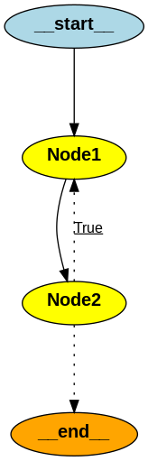

```python
from IPython.display import Image

Image(graph.get_graph().draw_png())
```

```python
states2 = []
for state in graph.get_state_history(thread2):
    states2.append(state.config)
    print(state.config, state.values['count'])
```

```
{'configurable': {'thread_id': '2', 'thread_ts': '1ef6b712-866e-6027-8004-618c8c091b67'}} 4
{'configurable': {'thread_id': '2', 'thread_ts': '1ef6b712-866b-6265-8003-128831faeecf'}} 3
{'configurable': {'thread_id': '2', 'thread_ts': '1ef6b712-8668-69ce-8002-baf94572853d'}} 2
{'configurable': {'thread_id': '2', 'thread_ts': '1ef6b712-8664-6557-8001-9cf6e169e123'}} 1
{'configurable': {'thread_id': '2', 'thread_ts': '1ef6b712-8661-65d2-8000-f766f9c587d7'}} 0
{'configurable': {'thread_id': '2', 'thread_ts': '1ef6b712-865f-62fe-bfff-66a632e7e538'}} 0
```

Start by grabbing a state.

```python
save_state = graph.get_state(states2[-3])
save_state
```

```
StateSnapshot(values={'lnode': 'node_1', 'scratch': 'hi', 'count': 1}, next=('Node2',), config={'configurable': {'thread_id': '2', 'thread_ts': '1ef6b712-8664-6557-8001-9cf6e169e123'}}, metadata={'source': 'loop', 'step': 1, 'writes': {'Node1': {'count': 1, 'lnode': 'node_1'}}}, created_at='2024-09-…
```

Now modify the values. One subtle item to note: Recall when agent state was defined, `count` used `operator.add` to indicate that values are *added* to the current value. Here, `-3` will be added to the current count value rather than replace it.

```python
save_state.values["count"] = -3
save_state.values["scratch"] = "hello"
save_state
```

```
StateSnapshot(values={'lnode': 'node_1', 'scratch': 'hello', 'count': -3}, next=('Node2',), config={'configurable': {'thread_id': '2', 'thread_ts': '1ef6b712-8664-6557-8001-9cf6e169e123'}}, metadata={'source': 'loop', 'step': 1, 'writes': {'Node1': {'count': 1, 'lnode': 'node_1'}}}, created_at='2024…
```

Now update the state. This creates a new entry at the *top*, or *latest* entry in memory. This will become the current state.

```python
graph.update_state(thread2,save_state.values)
```

```
{'configurable': {'thread_id': '2',
  'thread_ts': '1ef6b712-dffc-6415-8005-92dfb2a6f800'}}
```

Current state is at the top. You can match the `thread_ts`. Notice the `parent_config`, `thread_ts` of the new node - it is the previous node.

```python
for i, state in enumerate(graph.get_state_history(thread2)):
    if i >= 3:  #print latest 3
        break
    print(state, '\n')
```

```
StateSnapshot(values={'lnode': 'node_1', 'scratch': 'hello', 'count': 1}, next=('Node1',), config={'configurable': {'thread_id': '2', 'thread_ts': '1ef6b712-dffc-6415-8005-92dfb2a6f800'}}, metadata={'source': 'update', 'step': 5, 'writes': {'Node2': {'count': -3, 'lnode': 'node_1', 'scratch': 'hello…

StateSnapshot(values={'lnode': 'node_2', 'scratch': 'hi', 'count': 4}, next=(), config={'configurable': {'thread_id': '2', 'thread_ts': '1ef6b712-866e-6027-8004-618c8c091b67'}}, metadata={'source': 'loop', 'step': 4, 'writes': {'Node2': {'count': 1, 'lnode': 'node_2'}}}, created_at='2024-09-05T10:25…

StateSnapshot(values={'lnode': 'node_1', 'scratch': 'hi', 'count': 3}, next=('Node2',), config={'configurable': {'thread_id': '2', 'thread_ts': '1ef6b712-866b-6265-8003-128831faeecf'}}, metadata={'source': 'loop', 'step': 3, 'writes': {'Node1': {'count': 1, 'lnode': 'node_1'}}}, created_at='2024-09-…
```